# Visualizing Loans Awarded by Kiva

In this project we'll visualize insights using a dataset from [Kaggle](https://www.kaggle.com/fkosmowski/kivadhsv1). The dataset contains information about loans awarded by the non-profit [Kiva](https://www.kiva.org/).

Using Seaborn, we'll explore the average loan amount by country using aggregated bar charts. We'll also visualize the distribution of loan amounts by project type and gender using box plots and violin plots.

## Step 1: Import Necessary Python Modules

```python
from matplotlib import pyplot as plt
import pandas as pd
import seaborn as sns
```

## Step 2: Ingest The Data

```python
df = pd.read_csv('kiva_data.csv')
print(df.head())
```

```
   loan_amount               activity   country  gender
0          625  Food Production/Sales  Pakistan  female
1          250  Food Production/Sales  Pakistan  female
2          400  Food Production/Sales  Pakistan  female
3          400  Food Production/Sales  Pakistan  female
4          500  Food Production/Sales  Pakistan  female
```

## Step 3: Examine The Data

Each entry (row) in the dataset represents a loan that Kiva awarded to a particular project. The `loan_amount` column shows the amount (in U.S. dollars) awarded to the project. The `activity` column has the category type that the project falls under. The `country` column is the country where the project is located. The `gender` column represents the gender of the primary person who applied for the loan.

Print the first 25 rows of `df` using `.head()`

```python
print(df.head(25))
```

```
    loan_amount               activity   country  gender
0           625  Food Production/Sales  Pakistan  female
1           250  Food Production/Sales  Pakistan  female
2           400  Food Production/Sales  Pakistan  female
3           400  Food Production/Sales  Pakistan  female
4           500  Food Production/Sales  Pakistan  female
5           500  Food Production/Sales  Pakistan  female
6           400  Food Production/Sales  Pakistan  female
7           500  Food Production/Sales  Pakistan  female
8           400  Food Production/Sales  Pakistan  female
9           450  Food Production/Sales  Pakistan  female
10          250  Food Production/Sales  Pakistan  female
11          300  Food Production/Sales  Pakistan  female
12          275  Food Production/Sales  Pakistan  female
13          425  Food Production/Sales  Pakistan  female
14          425  Food Production/Sales  Pakistan  female
15          475  Food Production/Sales  Pakistan  female
16          225  Food Production/Sales  Pakistan  female
17          475  Food Production/Sales  Pakistan  female
18          525  Food Production/Sales  Pakistan  female
19          425  Food Production/Sales  Pakistan  female
20          475  Food Production/Sales  Pakistan  female
21          550  Food Production/Sales  Pakistan  female
22          450  Food Production/Sales  Pakistan  female
23          250  Food Production/Sales  Pakistan  female
24          600  Food Production/Sales  Pakistan  female
```

## Step 4: Bar Charts

Create a bar plot using Seaborn to visualize the average size of Kiva loans given to projects, by country.

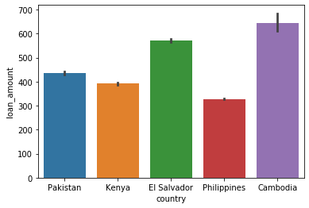

```python
# Create the bar plot using Seaborn
sns.barplot(data=df, x='country', y='loan_amount')
```

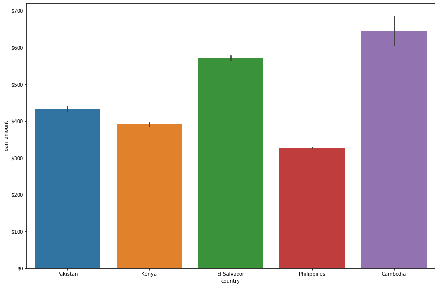

```python
import matplotlib.ticker as mtick

# Creates the figure
f, ax = plt.subplots(figsize=(15, 10))

# Plot the data
sns.barplot(data=df, x="country", y = "loan_amount")

fmt = '${x:,.0f}'
tick = mtick.StrMethodFormatter(fmt)
ax.yaxis.set_major_formatter(tick)
```

## Step 5: Learn More By Using `hue` In Visualization

We can visualize even more data on one bar plot by visualizing the loan amount by country, and "nesting" by gender. Add the `hue` parameter to `sns.barplot()` and set it so that the visualization includes the nested category of gender.

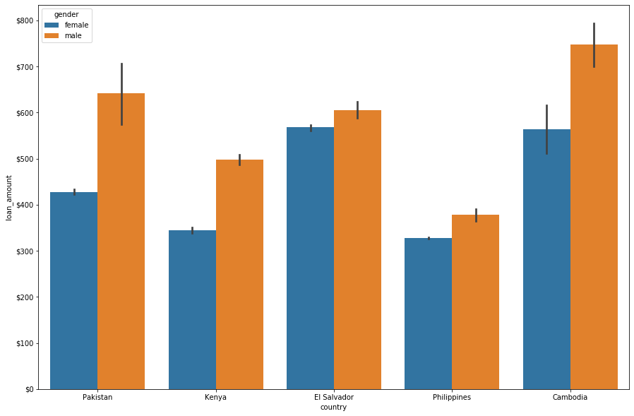

```python
# Create the figure
f, ax = plt.subplots(figsize=(15, 10))

sns.barplot(data=df, x="country", y="loan_amount", hue='gender')

fmt = '${x:,.0f}'
tick = mtick.StrMethodFormatter(fmt)
ax.yaxis.set_major_formatter(tick)
```

On average, we see that males receive larger loans across inspected countries.

```python
av_loan = df.groupby('gender').loan_amount.mean()
print(av_loan)
```

```
gender
female    353.179761
male      496.263253
Name: loan_amount, dtype: float64
```

```python
least_loan_amount = df.groupby('country').loan_amount.min()
print(least_loan_amount)
```

```
country
Cambodia       100
El Salvador    100
Kenya           50
Pakistan       100
Philippines     50
Name: loan_amount, dtype: int64
```

Based on the data inspected, we can recomment that Kiva should work on decreasing the gender loan gap. Kiva could make a requirement on making loan amounts for both genders more or less equal.

## Step 6: Styling

We can also set a different color palette using `sns.set_palette()`. Let's use one of the Color Brewer qualitative color palettes:

- Set1
- Set2
- Set3
- Pastel1
- Pastel2
- Dark2
- Accent

More on styling is here [qualitative color palettes in the Seaborn documentation.](https://seaborn.pydata.org/tutorial/color_palettes.html#qualitative-color-palettes)

Let's also set the plot background style using `sns.set_style()`.

- whitegrid
- darkgrid
- white
- dark

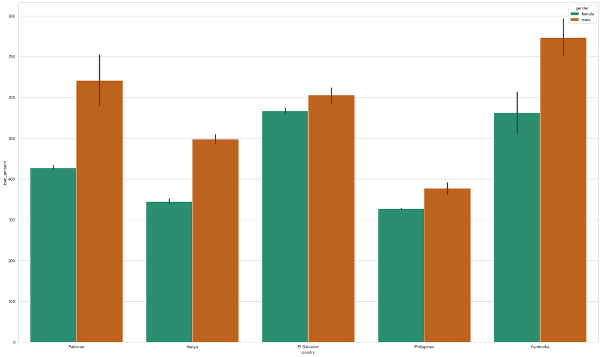

```python
# Set color palette
sns.set_palette('Dark2')

# Set style
sns.set_style('whitegrid')

# Create figure and axes (no need to use the previous syntax, as the y-label ticks aren't going to be formatted)
plt.figure(figsize=(25, 15))

# Add a title
ax.set_title('Kiva Loans by Gender')

# Use Seaborn to create the bar plot
sns.barplot(data=df, x='country', y='loan_amount', hue='gender')
```

## Step 7: Box Plots With Kiva Data

Let's use `sns.boxplot()` to compare the distribution of loan amounts by country for the Kiva dataset.

`sns.boxplot()` can be passed the same parameters as `sns.barplot()`.

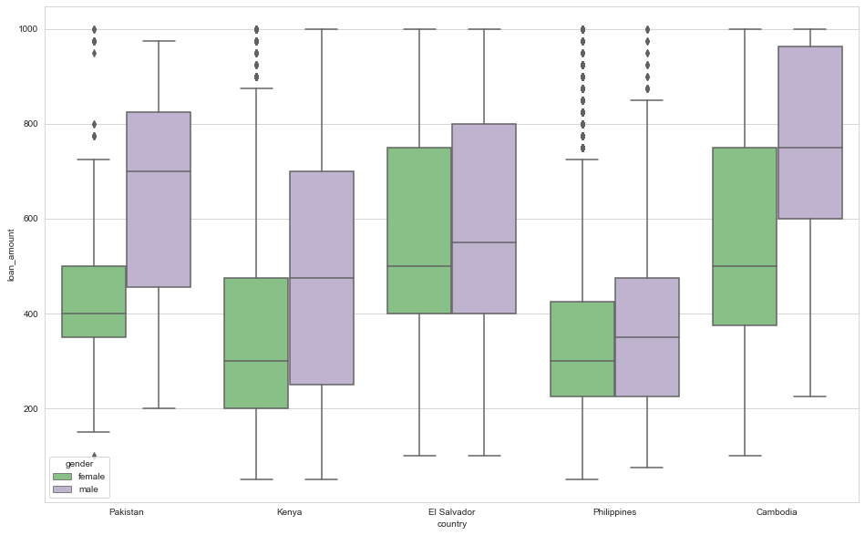

```python
plt.figure(figsize=(16, 10))
sns.set_palette('Accent')
sns.boxplot(data=df, x='country', y='loan_amount', hue='gender')
```

From this plot, we can see that Kenya has the widest distribution.\ Cambodia is the country where you are most likely to receive the largest loan amount.

## Step 8: Box Plot by Activity

Let's use `sns.boxplot()` to plot the loan amount by *activity*.

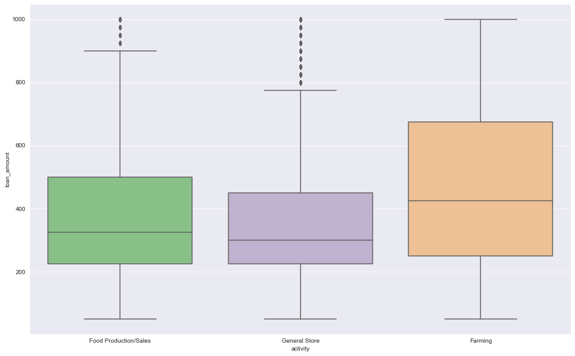

```python
plt.figure(figsize=(16, 10))
sns.set_palette('Accent')
sns.set_style('darkgrid')
sns.boxplot(data=df, x='activity', y='loan_amount')
```

This visualization reveals that farming businesses are more likely to get bigger loan, and they do get bigger loan, on average.\ Farming also has the widest distribution among inspected businesses.

## Step 9: Violin Plots

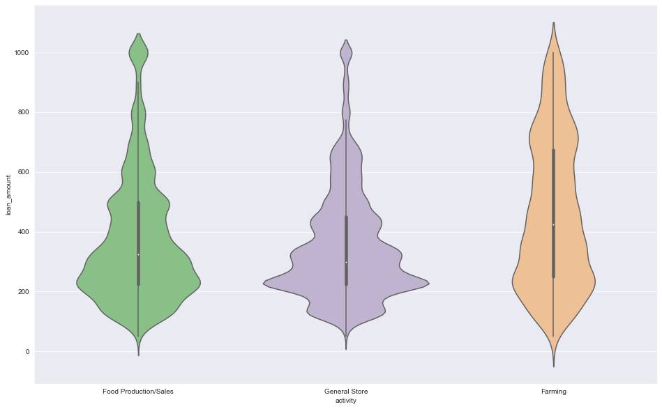

```python
plt.figure(figsize=(16, 10))
sns.violinplot(data=df, x="activity", y="loan_amount")
```

### Create a violin plot that visualizes the distribution of loan amount by country.

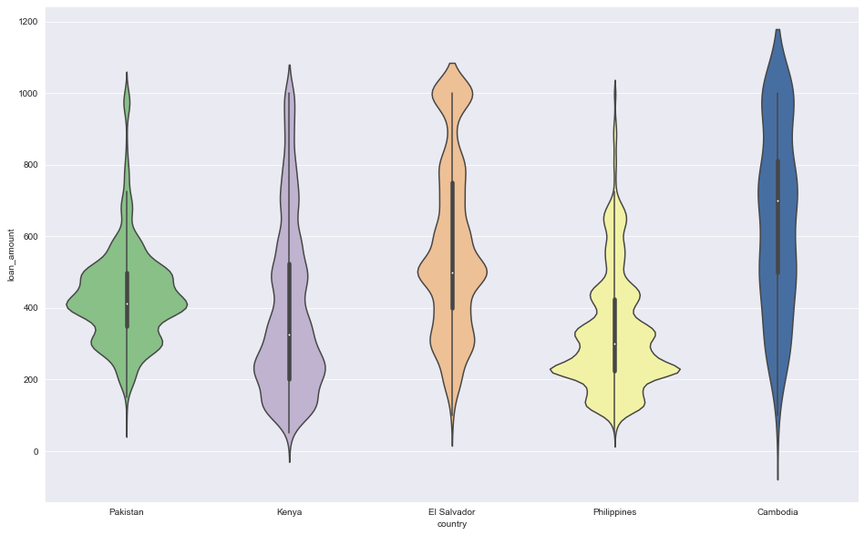

```python
plt.figure(figsize=(16, 10))
sns.violinplot(data=df, x='country', y='loan_amount')
```

## Step 10: Split Violin Plots

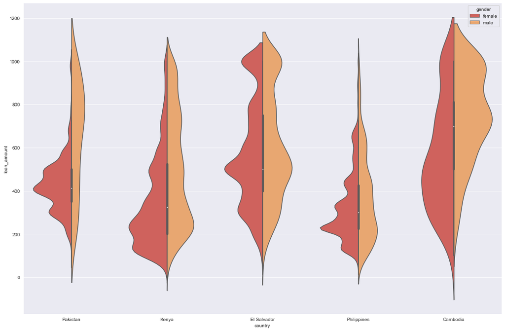

```python
# Styling
sns.set_palette("Spectral")
plt.figure(figsize=(18, 12))
sns.violinplot(data=df, x='country', y='loan_amount', hue='gender', split=True)
```

Analyzing these violin plots, we can see that on average, men get much bigger loan amount in Pakistan and Cambodia, while in El Salvador, the distribution of loans is more or less equal.